# hw3

Tariq Anwar

February 3, 2016

## Question 1 (a)

Since it is given that population variance is equal. We can test the NULL hypothesis as

$H_0 : \mu_c - \mu_s = 0$

againts the alternative hypothesis

$H_a : \mu_c - \mu_s \neq 0$

using the test statistic

$t = \dfrac {(\bar X - \bar Y) - (\mu_c -\mu_s)} {S_p\sqrt {\dfrac{1}{n} + \dfrac {1}{m}} }$

$t = \dfrac {(12.25 - 15.25) - 0} {S_p\sqrt {\dfrac{1}{15} + \dfrac {1}{12}} }$

The $S_p$ standard deviation can be calculated as

$S_p = \sqrt{\dfrac {14(3.3)^2 +11(3.6)^2} {25}} = 3.4352292$

So the test statistic is: $t = -2.2548618$

Calculating the P-value for $P = 2*P(T_{25}>t) = 2*0.016605 = 0.03321$

Therefore beacause P is less than $=0.05 $ we reject the null hypothesis in favor of alternative i.e it is justified in concluding that caffeine impairs recall ability.

### Question 1.b when population variance are not equal.

$t = \dfrac {12.25-15.25}{\sqrt{\dfrac{3.3^2}{15} + \dfrac{3.6^2}{12}}} = -2.2323505$

Degree of freedom (r) can be calculated as:

$r = \dfrac {(\dfrac {3.3^2}{15} + \dfrac {3.6^2}{12})^2} { \dfrac{1}{14} (\dfrac{3.3^2}{15})^2 + \dfrac{1}{11} (\dfrac{3.6^2}{12})^2}=22.6999614 = 23$

As $t=2.23 > t_{0.025,23} = 2.069$ We reject the null hypothesis

## Question 1.c

### i) Individual Confidence interval

```r
a<- 15.25
s<-3.3
n<-15
error <- qt(0.975,df=n-1)*s/sqrt(n)
left <- a-error
left
```

```
## [1] 13.42252
```

```r
right <- a+error
right
```

```
## [1] 17.07748
```

```r
#second
a<- 12.25
s<-3.6
n<-12
error <- qt(0.975,df=n-1)*s/sqrt(n)
left <- a-error
left
```

```
## [1] 9.962669
```

```r
right <- a+error
right
```

```
## [1] 14.53733
```

### ii)

the 95% confidence interval tells about the confidence level that the 95 % of time the mean of samples will fall under the interval A 95% confidence interval has a 0.95 probability of containing the population sample mean. 95% of the population distribution is contained in the confidence interval. The 95% confidence interval is not the interval that contains 95% of recalled words, instead it tells about the probablity that the if any random sample is taken from population it will fall under that interval 95% of time and not the other way round.

### iii)

Degree of freedom according to Welch t interval

$r = \dfrac {(\dfrac {3.3^2}{15} + \dfrac {3.6^2}{12})^2} { \dfrac{1}{14} (\dfrac{3.3^2}{15})^2 + \dfrac{1}{11} (\dfrac{3.6^2}{12})^2}=22.6999614 = 23$

Using T -table we calculate t value = $t_{0.025,23} = 2.069$

### Question 1.d

Both approaches have advantage in different situation:

Hypothesis testing should be used when we want strict comparison with a pre-specified hypothesis and significance level.

Confidence interval is better suited for magnitude of an effect (mean difference, proportion) or when we need to describe a single sample.

## Question 2

```r
prop.test((60/100)*1024, 1024, conf.level=0.95, correct = FALSE)
```

```
##
##  1-sample proportions test without continuity correction
##
## data:  (60/100) * 1024 out of 1024, null probability 0.5
## X-squared = 40.96, df = 1, p-value = 1.554e-10
## alternative hypothesis: true p is not equal to 0.5
## 95 percent confidence interval:
##  0.5696744 0.6295782
## sample estimates:
##   p
## 0.6
```

```r
prop.test((60/100)*1024, 1024, conf.level=0.90, correct = FALSE)
```

```
##
##  1-sample proportions test without continuity correction
##
## data:  (60/100) * 1024 out of 1024, null probability 0.5
## X-squared = 40.96, df = 1, p-value = 1.554e-10
## alternative hypothesis: true p is not equal to 0.5
## 90 percent confidence interval:
##  0.5745867 0.6248862
## sample estimates:
##   p
## 0.6
```

The 95% confidence interval is wider because the greater the confidence level, the more confident we can be that the confidence interval contains the actual population parameter and it has more area under it.

### Question2.b

$Effect Size(ES) = \dfrac {0.05}{\sqrt{0.55(1-0.55)}} = 0.1005038$

$n = \dfrac {Z_{1-\alpha/2 } + Z_{1-\beta}}{ES } = 784$

## Question 3

### 1

Since it $\bar x_1 and \bar x_2$ represent sample mean , it can not be true. The hypothesis testing is done on population mean not on samples, hence this statement is wrong.

### 2

Since the study is done using independent two-sample t-test and in this case one sample contains the entire population , hence this is not independent.The requirement of T-test is that the sample should be independent.

### 3

P value of range 0.94 is within the confidence level of 90% so the null hypothesis in this case can not be rejected.

### 4

Since the p-value of alternative hypothesis is 3.6 % and it is less than 0, the area will be divided into two parts for t. The first part will be area to the right of t value. The second part will have area to the left of t value. The area to the right will be 1.8 % where as the area to the left of t-value will be 100-1.8%.

## Question 4

### a

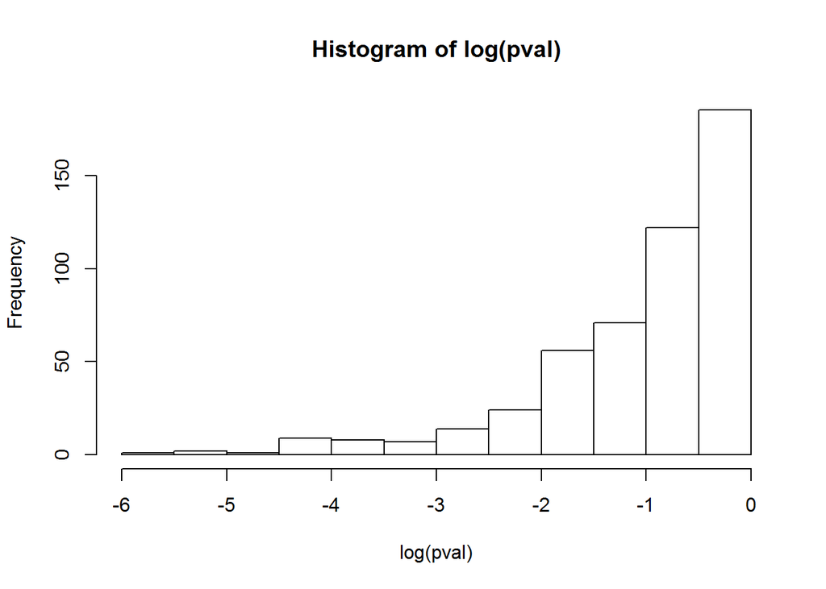

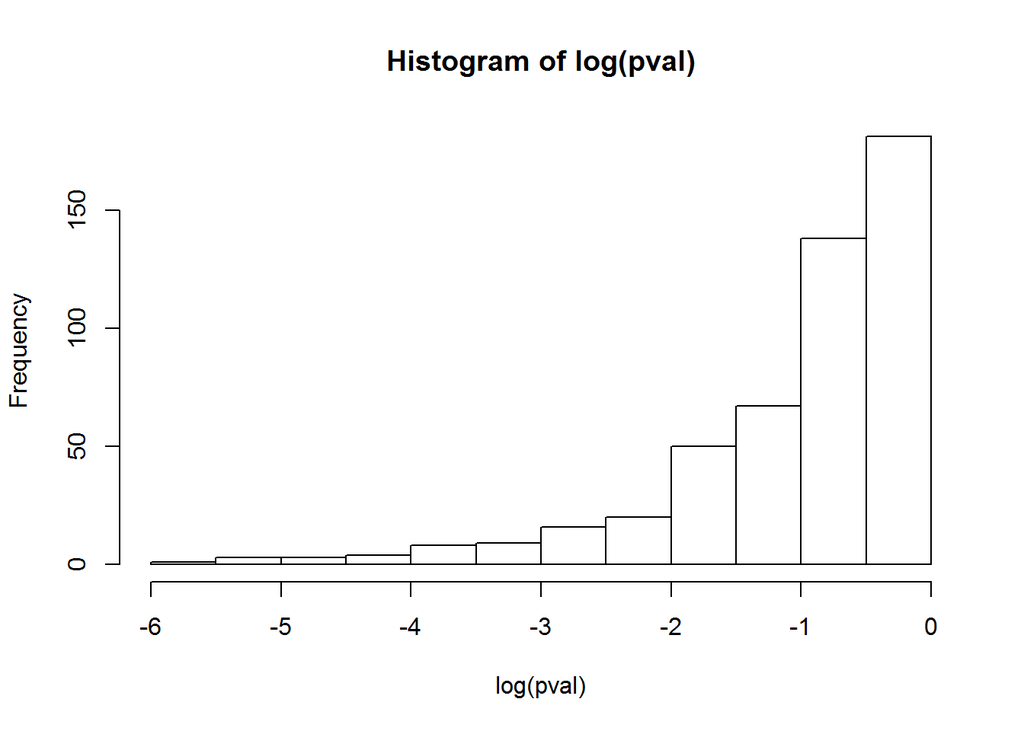

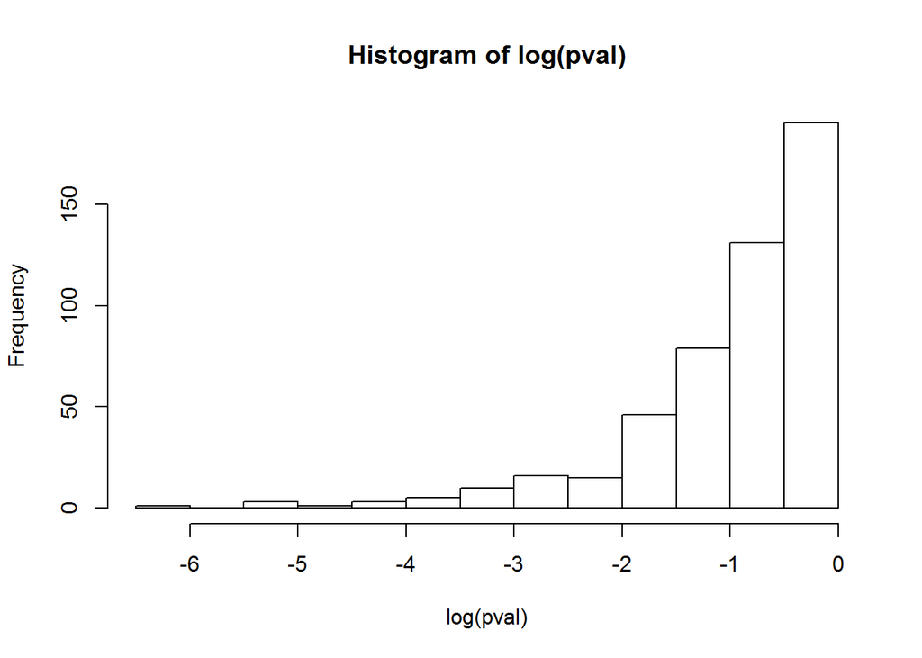

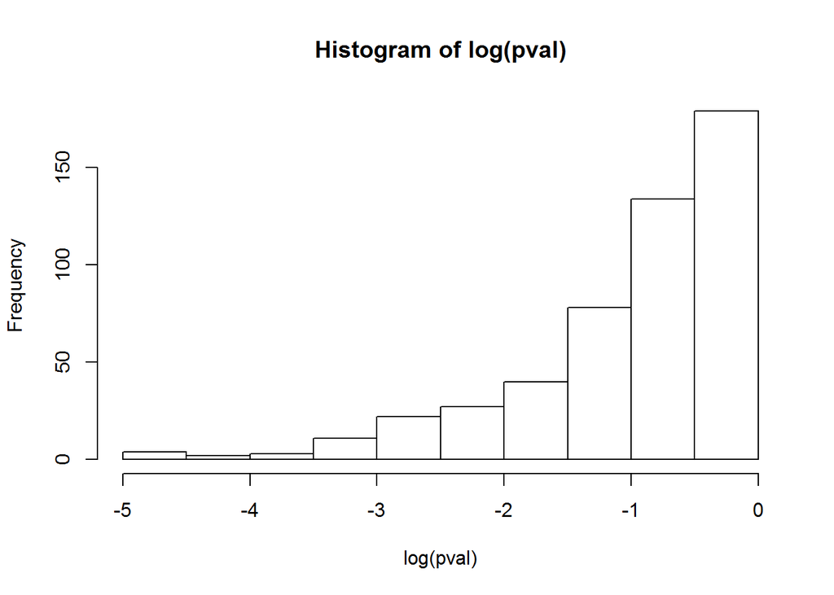

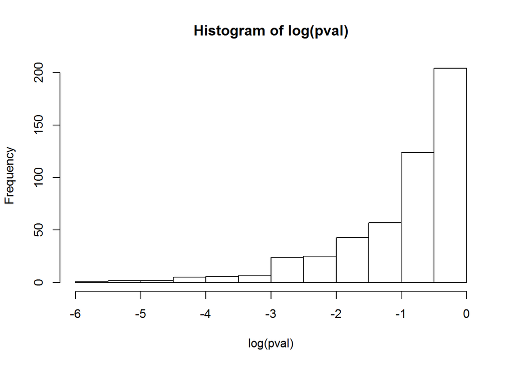

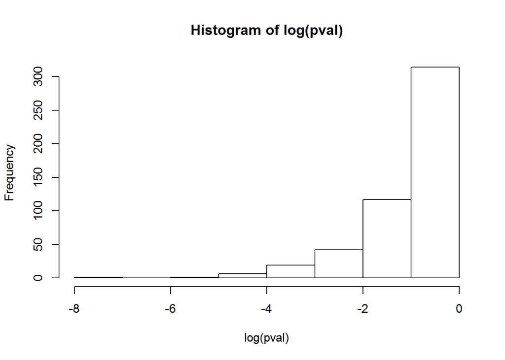

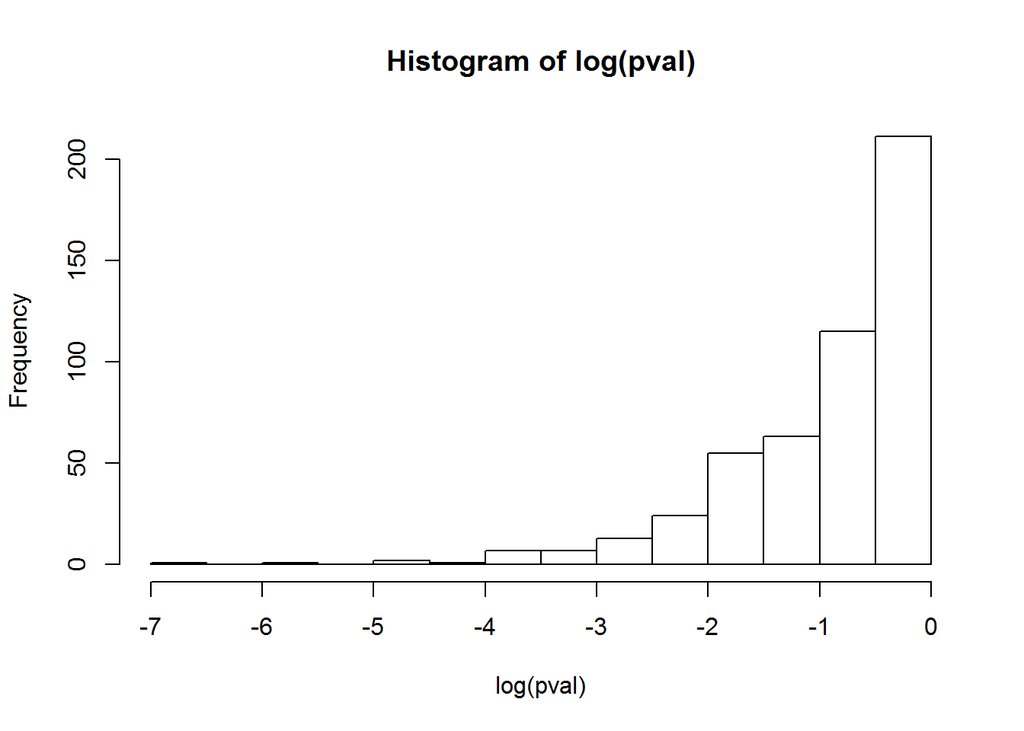

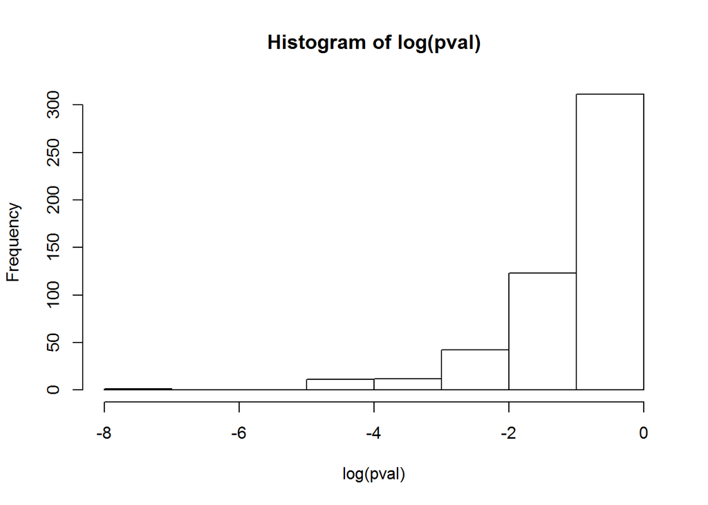

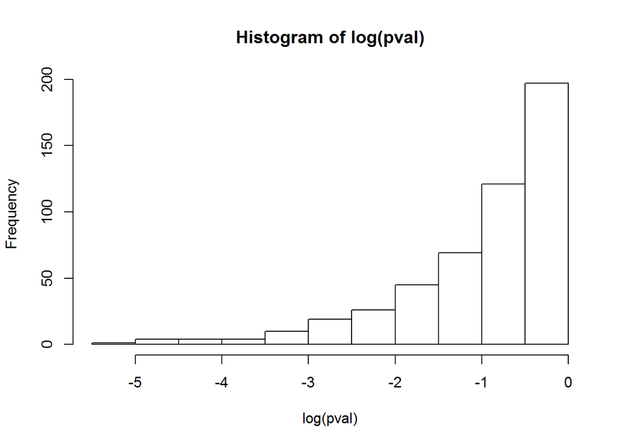

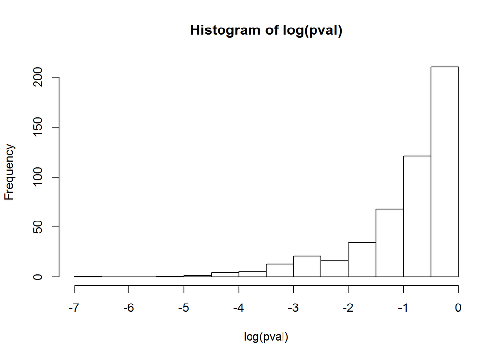

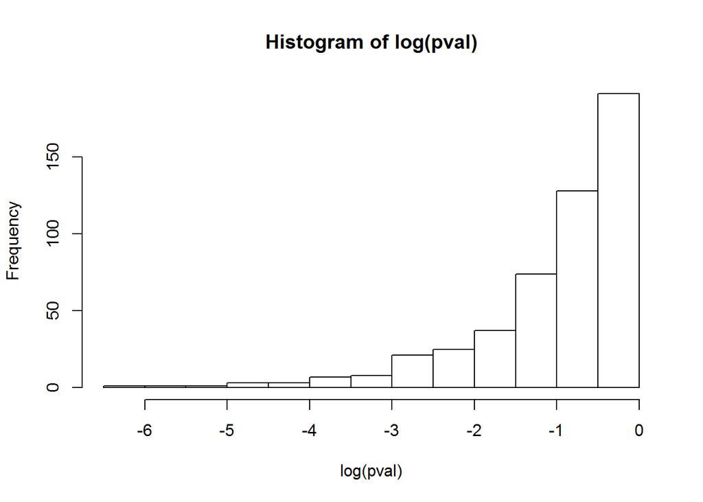

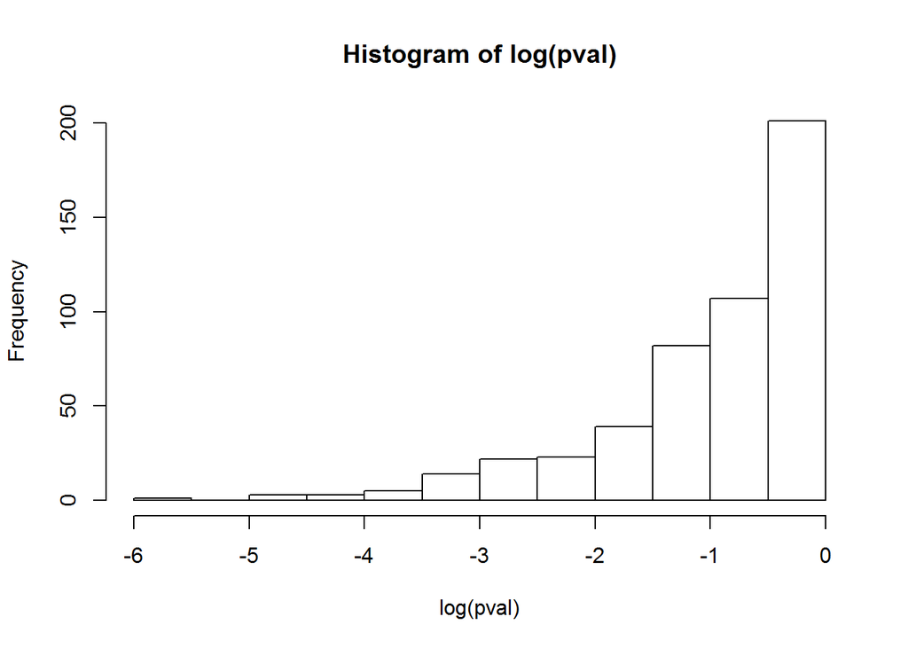

[13 more figures not shown]

```r
m<-c(0,0.5,1,2,3)
sd<-c(0.01,0.25,0.5,1,2)
c<- expand.grid(a=m,b=sd)

##sample size of 10


t.test.stats <- function(m,s,n,samp) {
  pval<- integer(length = 0)
  for(i in 1:n){
   d<- rnorm(samp, m, s)
   e<- rnorm(samp,m,s)
  pval[i]<-  (t.test(d,e)$p.value)
}
 hist(log(pval))
}

invisible(mapply(t.test.stats,c$a,c$b,500,10))
```

## Question4.b

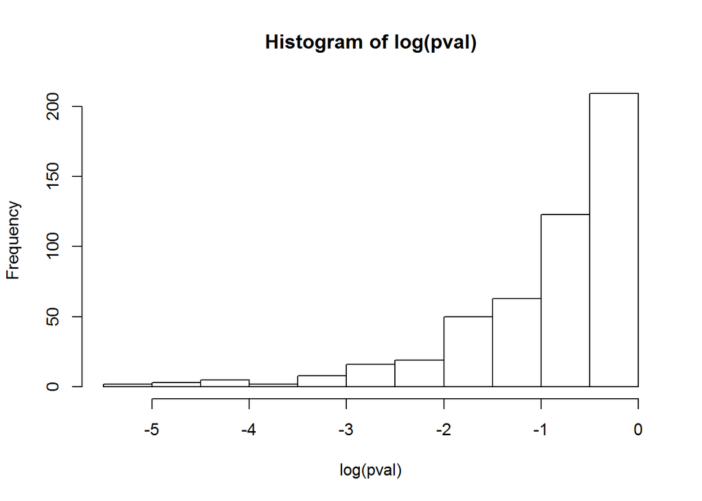

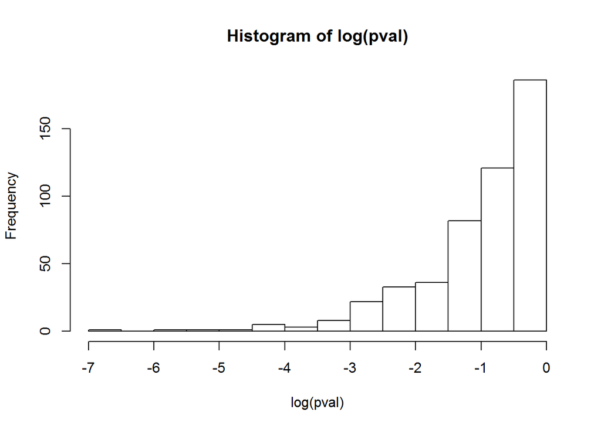

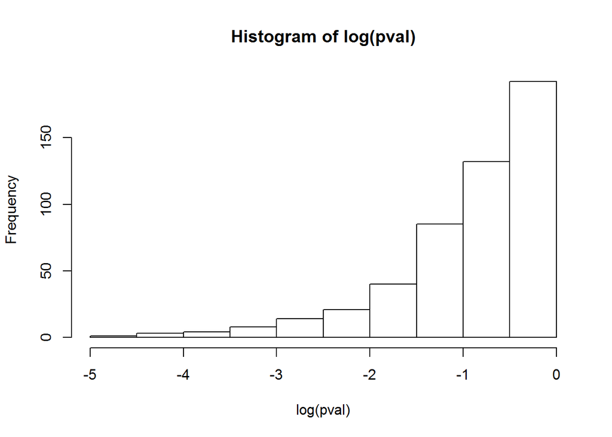

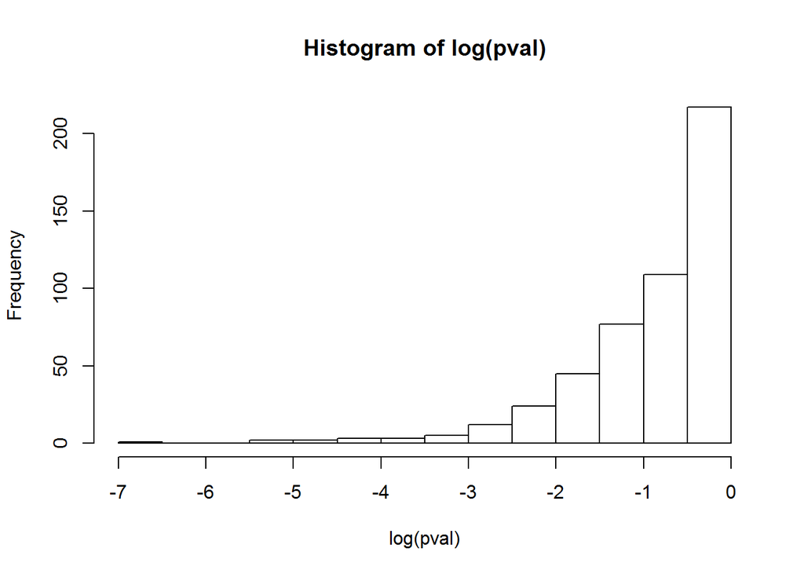

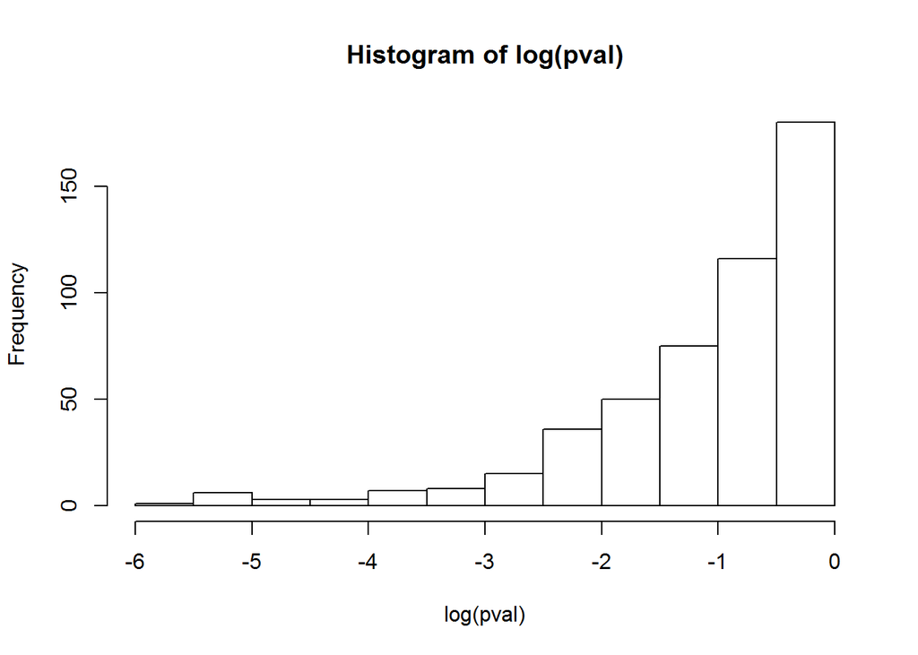

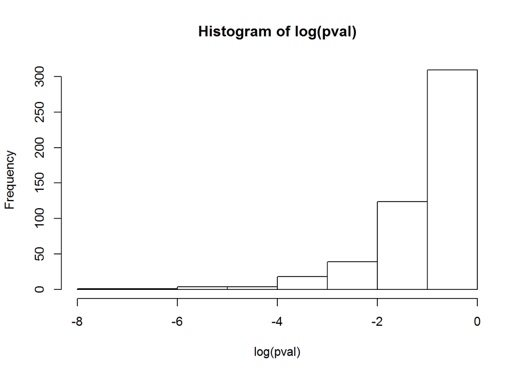

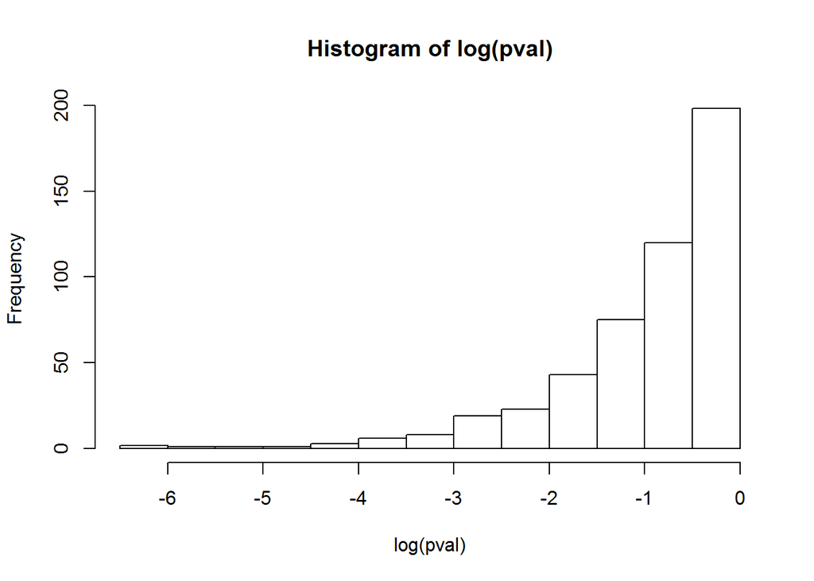

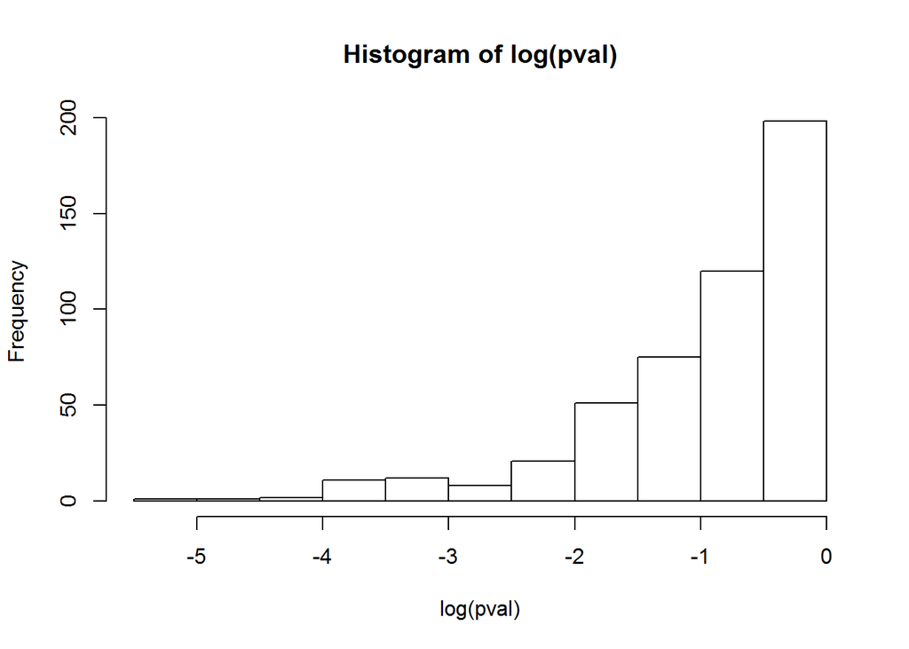

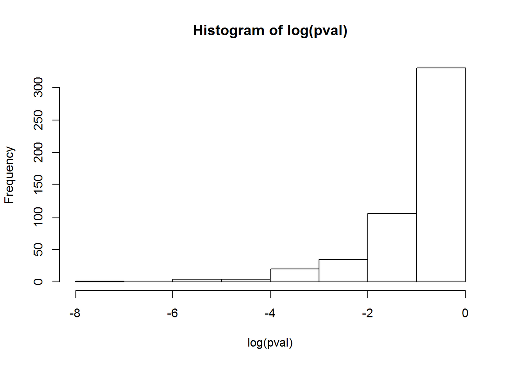

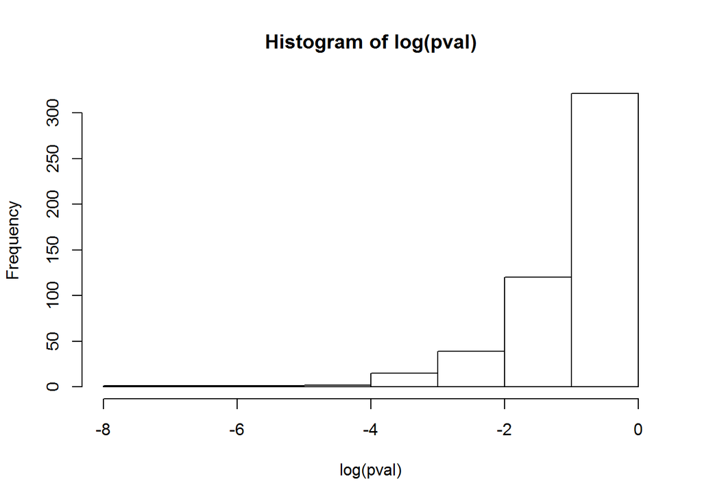

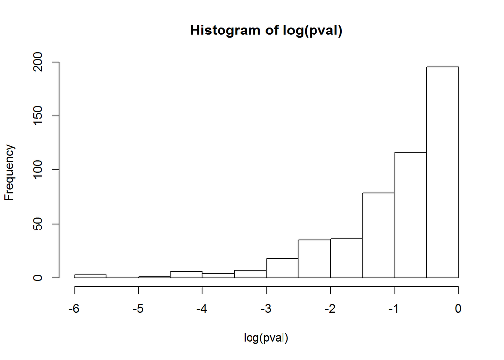

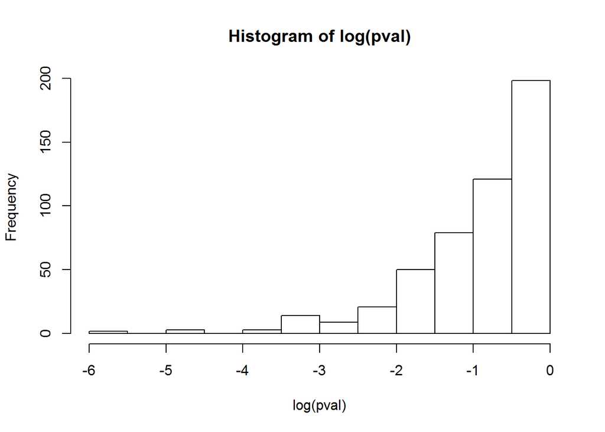

[13 more figures not shown]

```r
invisible(mapply(t.test.stats,c$a,c$b,500,30))
```

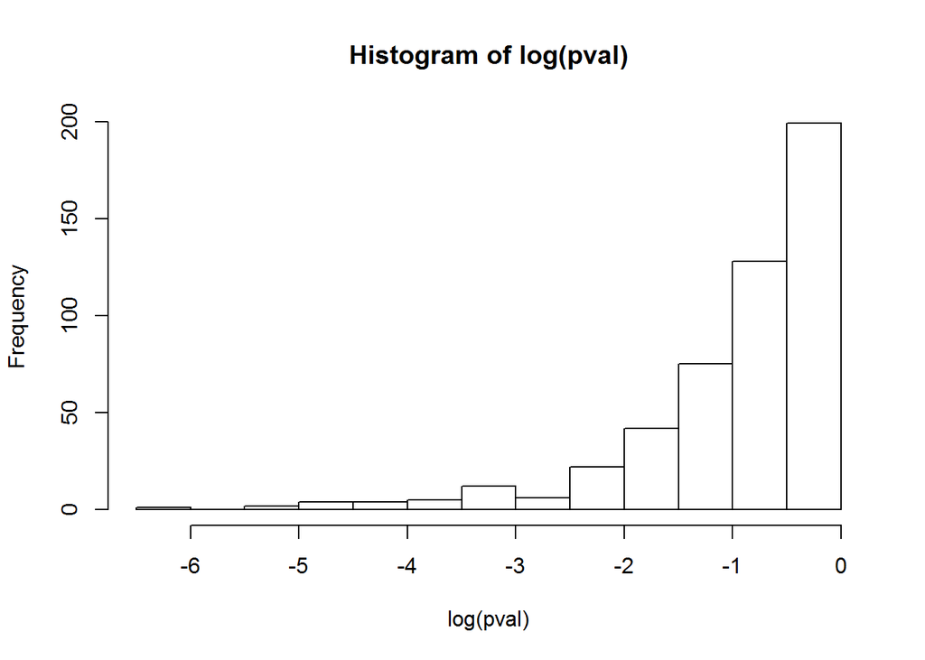

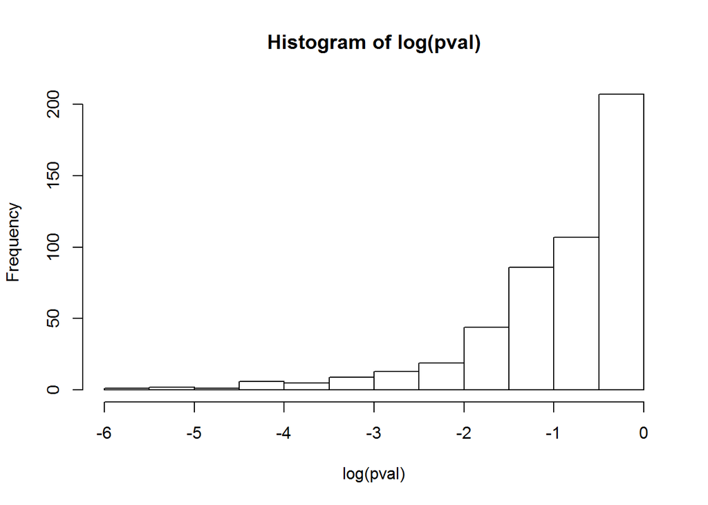

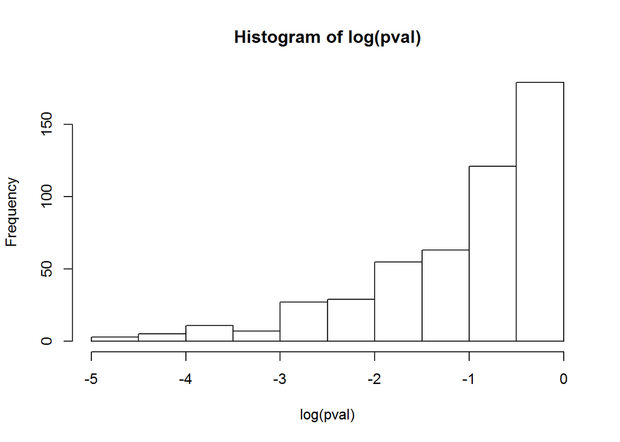

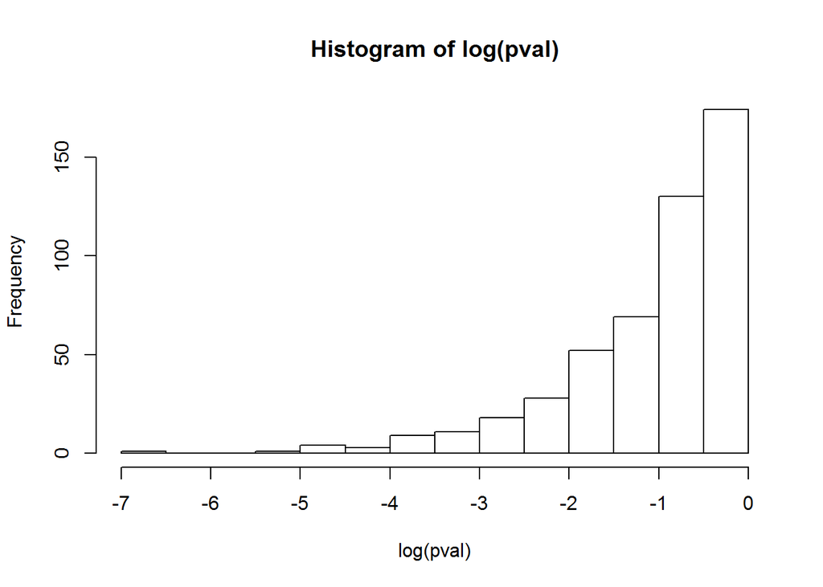

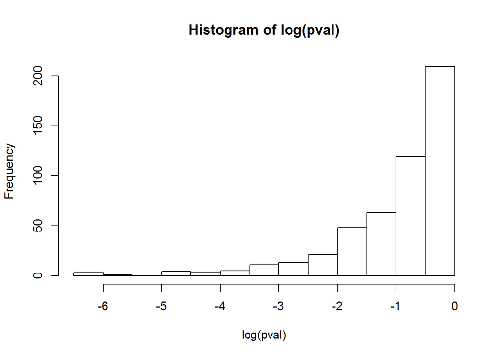

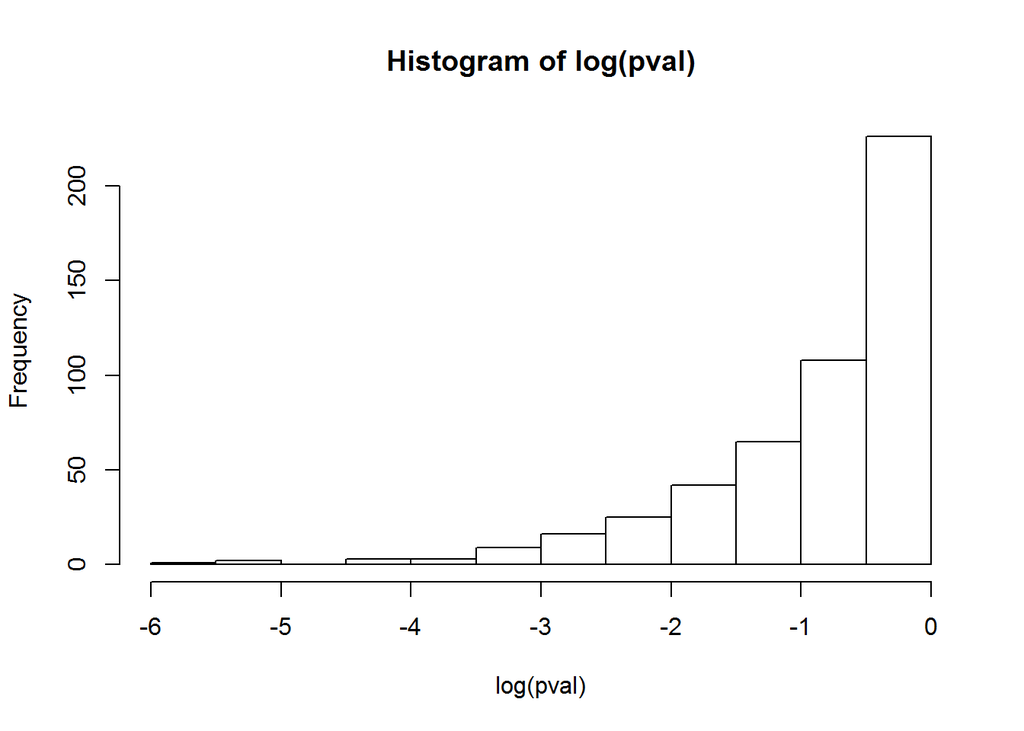

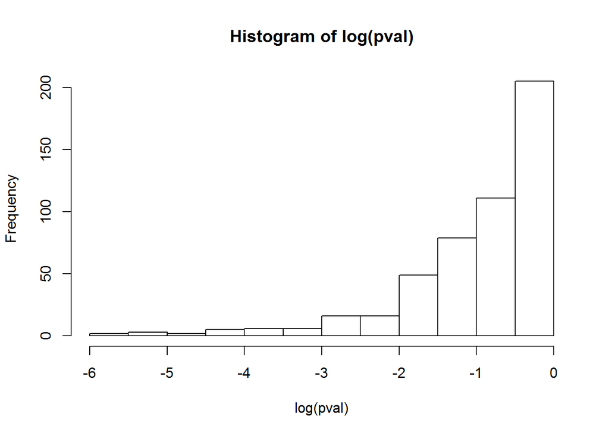

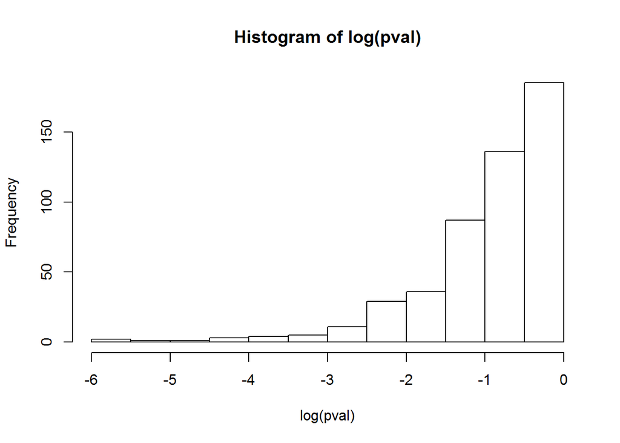

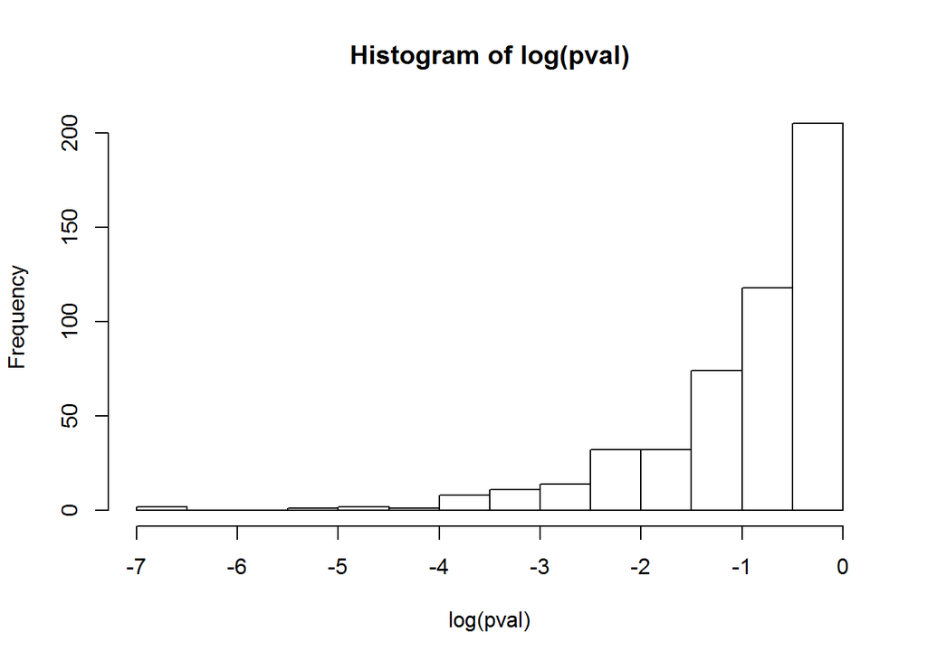

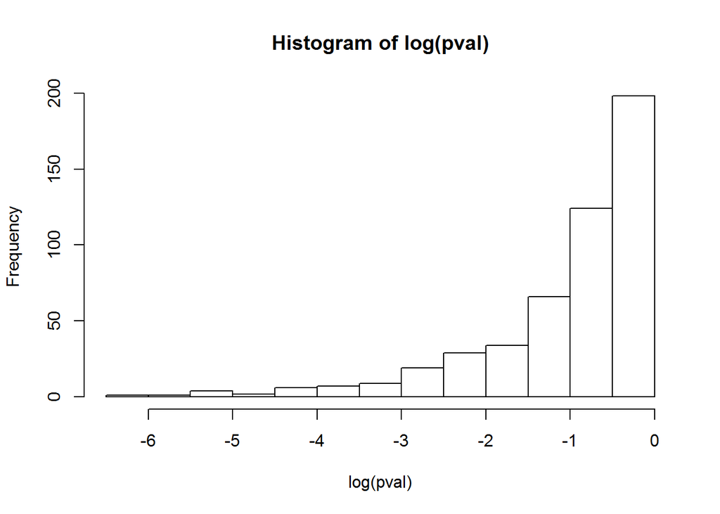

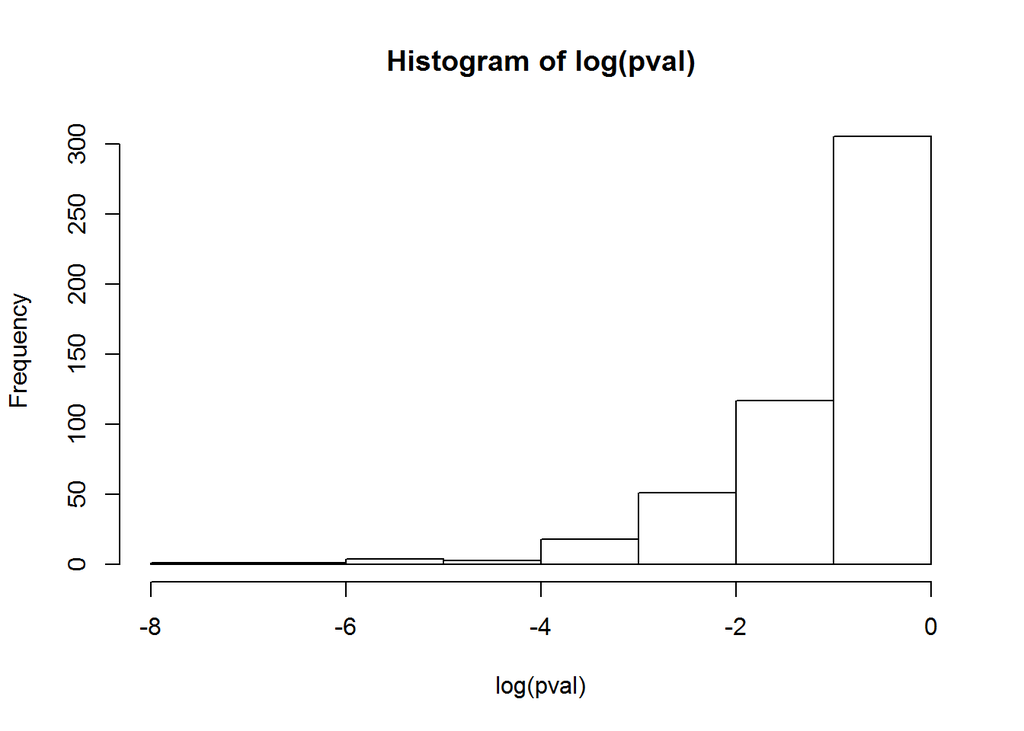

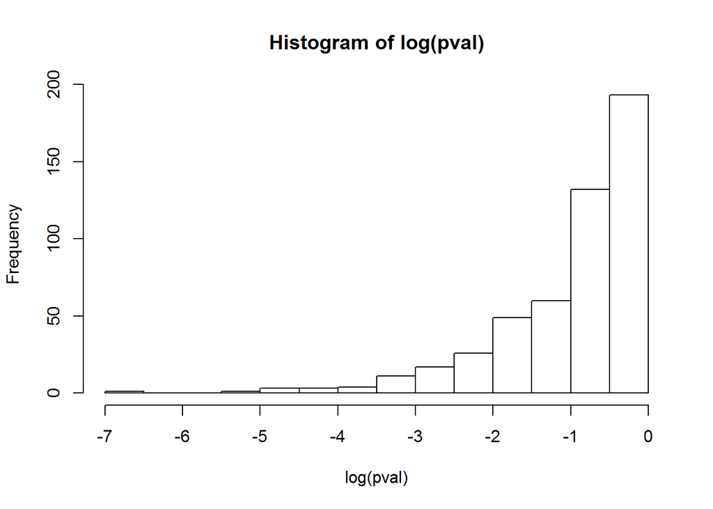

[13 more figures not shown]

```r
#### for 300
invisible(mapply(t.test.stats,c$a,c$b,500,300))
```

## Question4.c

Observation: